# final_project

# Interpretation of summaries: Model 1

## Estimates

The values for the coefficients of model 1 indicate that for every 1% increase in the prevalence of anemia among women of reproductive age, the fertility rate, total (births per woman) increases by 0.018960. On the other hand, for every 1% increase in pregnant women receiving prenatal care (%), the fertility rate decreases by 0.010615, and for every 1% increase in contraceptive prevalence (% of women ages 15-49), the fertility rate decreases by 0.044911

## Standard Errors

We’ve already interpreted that for every 1% increase in the prevalence of anemia among women of reproductive age, the fertility rate increases by 0.018960. We can say that for every 1% increase in the prevalence of anemia, the change in fertility rate can vary by 0.008437. And for every 1% increase in pregnant women receiving prenatal care and in the prevalence of contraception, the change in maternal mortality ratio can vary by 0.006089 and 0.004304 accordingly.

## t-value

The t-value is a measure of how many standard deviations our coefficient estimate is far away from 0. We want it to be far away from zero as this would indicate we could reject the null hypothesis - that is, we could deduce that a relationship between the predictors and the outcome exists. In our model, the t-statistic values are slightly far from zero and are larger than the standard error, which could indicate a relationship exists.

# Interpretation of summaries: Model 2

The values for the coefficients of model 2 indicate that for every 1% increase in the prevalence of anemia among women of reproductive age, the fertility rate, total (births per woman) increases by 0.066240. On the other hand, for every 1% increase in pregnant women receiving prenatal care(%), the fertility rate decreases by 0.024168.

## Standard Errors

We can say that for every 1% increase in the prevalence of anemia, the change in fertility rate can vary by 0.009332. And for every 1% increase in pregnant women receiving prenatal care, the change in maternal mortality ratio can vary by 0.007801.

## t-value

In our model, the t-statistic values are slightly far from zero and are larger than the standard error, which could indicate a relationship exists.

## p-value

In our model, the p-values for the intercept and the slope are very close to zero (<0.05). which indicates that we can reject the null hypothesis which allows us to conclude that there is a relationship between the predictor (anemia) and outcome (fertility rate). Whether the relationship is practically significant will be discussed below.

## Adjusted R-squared

The adjusted R-squared value for model 1 is 0.6427, while the value for model 2 is 0.3857. Model 1 has the higher R-squared value, indicating that model 1 fits the data better than model 2.

# F-test

```r
anova(model2.1,model2.2)
```

```
## Analysis of Variance Table
##
## Model 1: fertilityrate ~ prenatalcare + contraceptives + anemia
## Model 2: fertilityrate ~ prenatalcare + anemia
##   Res.Df    RSS Df Sum of Sq     F    Pr(>F)
## 1    149 111.45
## 2    150 192.91 -1   -81.459 108.9 < 2.2e-16 ***
## ---
## Signif. codes:  0 '***' 0.001 '**' 0.01 '*' 0.05 '.' 0.1 ' ' 1
```

```r
#The test chooses model 1 (the full model) over the reduced model (model 2) because the p-value is smaller than 0.05.
#The data supports that the coefficients not shared between the models are not zero.
```

```r
confint(model2.1,level=0.95)
```

```
##                       2.5 %       97.5 %
## (Intercept)     4.409168898  7.188817096
## prenatalcare   -0.022647596  0.001417422
## contraceptives -0.053414946 -0.036406751
## anemia          0.002288373  0.035631485
```

```r
confint(model2.2,level=0.95)
```

```
##                    2.5 %       97.5 %
## (Intercept)   1.64279520  5.080548283
## prenatalcare -0.03958122 -0.008754097
## anemia        0.04779961  0.084679472
```

# Interpreting confidence intervals

The output indicates that a 95% confidence interval for our intercept estimate is [4.409168898, 7.188817096] for model 1 and [1.64279520 5.080548283] for model 2. This means that we can be 95% certain that our intercept value will fall between these values for model 1 and model 2, and that if multiple confidence intervals were constructed for our intercept estimate, 95% of the intervals would include the true intercept value.

The confidence interval for our main predictor estimate (anemia) is [0.002288373, 0.035631485] for model 1 and [0.04779961, 0.084679472] for model 2, which means that we can be 95% certain that the value of our anemia slop will fall between these values, and that if multiple confidence intervals were constructed for our slope estimate, 95% of the intervals would include the true value.

# statistical and practical significance of the main predictor (prevalence of anemia)

Since the p-value of the main predictor (prevalence of anemia) is very close to zero (<0.05) in both models, we can conclude that the predictor is statistically significant - there is a significant relationship between the prevalence of anemia among women of reproductive age and fertiliy rate. Practical significance refers to the relationship between the variables and the real world situation, and is generally assessed with some measure of effect size and external factors like cost and time. In our example, we are trying to measure the effect that the prevalence of anemia in women of reproductive age on the population’s fertility rate. Based on the values of the 95% confidence intervals - we know that for every 1% increase in the prevalence of anemia among women, there will be between a 0.002288373 to 0.035631485 increase in the fertility rate (model 1), and between a 0.04779961 to 0.084679472 increase in the fertility rate (model 2). At a first glance, it seems impossible that having more women suffer from anemia leads to an increased fertility rate in the population, and having more prenatal care leads to a decreased fertility rate. Based on the units of the variables, although the data indicates statistical significance, a 1% increase in the prevalence of anemia leads to less than 0.085 increase in births per woman. Unlike the models of the first outcome variable that measured the relationship between the predictors and the maternal mortality ratio, the relationship between the predictors and the second outcome variable, fertility rate, seems practically insignificant.

# Diagnostic plots

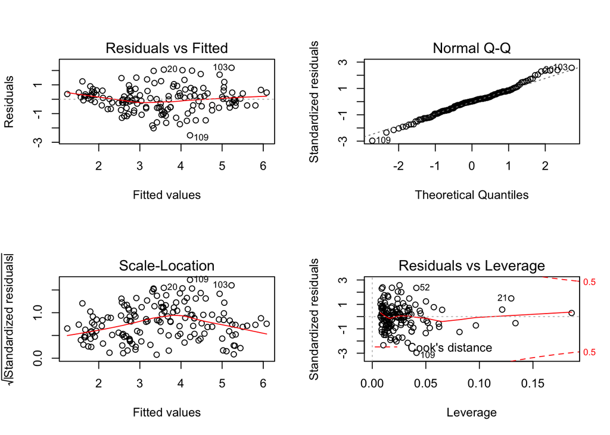

```r
par(mfrow=c(2,2))
plot(model2.1)
```

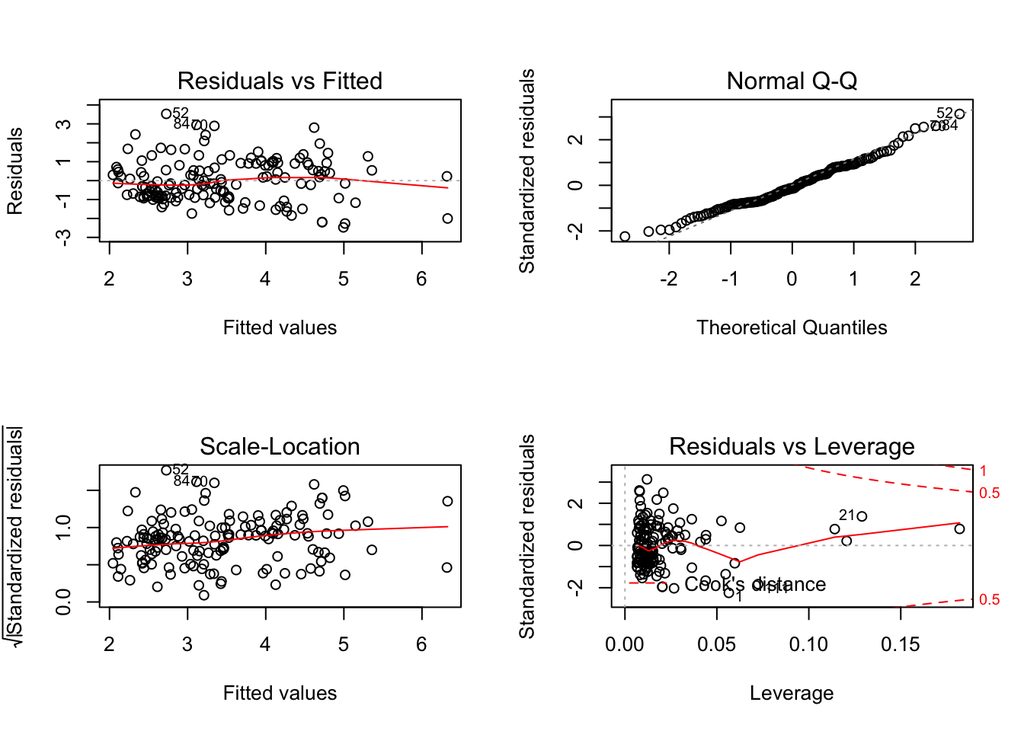

```r
plot(model2.2)
```

# Interpretation of the regression diagnostic plots

## Residuals vs. Fitted

In both models, there is no pattern in the residual plot and the line is approximately horizontal at zero. This suggests that we can assume linear relationship between the predictors and the outcome variables.

## Scale-Location

In model 1, there are several areas where the points are clustered together, and in model 2, the residuals begin to spread wide along the x-axis as it passes around 4. Due to the residuals spreading wider apart after this point, the red line is not horizontal and shows a slightly positive angle.

## Normal Q-Q

In both models, almost all of the points fall approximately along this reference line, so we can assume normality.

## Summary of overall conclusions

Given the interpretations of the coefficients for the chosen predictor variable (prevalence of anemia among women of reproductive age), both models do not match my initial predictions that there is a negative relationship between the prevalence of anemia among women of reproductive age and fertility rate. While the results indicated a positive relationship that was statistically significant, the relationship does not seem practically significant given the units of the outcome variable being total births per woman. The results also did not match my expectations about the positive relationship between pregnant women receiving prenatal care and fertility rate, as there was a negative relationship that also seems practically insignificant. The results did match my initial expectation that there will be a negative relationship between the prevalence of contraceptives and fertility rate. Based on the r-squared values and F-test, the full model (model 1) appears to better represent the data / tell the most accurate story than model 2, which excluded the prevalence of contraceptives predictor variable. The estimated value of the main predictor variable (anemia) is smaller in model 1 compared to model 2. Perhaps this is because the prevalence of contraceptives led to a reduced fertility rate, causing a greater increase in the fertility rate per every 1% increase in the prevalence of anemia in model 2, which did not account for the prevalence of contraceptives in the population.

# Conclusion

My initial predictions for the first outcome variable was the following: As the prevalence of anemia among women of reproductive age increases, there will be an increase in the maternal mortality ratio, indicating a positve relationship between the predictor and outcome variables. I further predicted that as the % of pregnant women receiving prenatal care and the prevalence of contraceptives among women of reproductive age increases, there will be a decrease in the maternal mortality ratio, indicating a negative relationship between the predictor and outcome variables. The results generally matched my predictions, and I am inclined to declare a causal relationship between the prevalence of anemia and the maternal mortality ratio. In interpreting the regression diagnostic plots for the first outcome variable, I found an outlier - Sierra Leone, which was found as having the highest maternal mortality ratio in the world and likely influenced the results.